# Data Wrangling

## Car Evaluation Sample Project - Part 2

### Car Evaluation Dataset: https://archive.ics.uci.edu/ml/datasets/Car+Evaluation

#### I uploaded the dataset on my github, you can find it here: https://github.com/mmouty/energynds/blob/main/energynds/assets/datasets/auto.csv

#### Data type: csv

# Second Step: Data Wrangling

### Identifying and handling missing values

#### 1. Identify missing data

In our dataset, the missing data comes with the question mark "?", so let's replace ? with NaN:

```python
df.replace("?", np.nan, inplace = True)
df.head(5)
```

|  | symboling | normalized-losses | make | fuel-type | aspiration | num-of-doors | body-style | drive-wheels | engine-location | wheel-base | ... | engine-size | fuel-system | bore | stroke | compression-ratio | horsepower | peak-rpm | city-mpg | highway-mpg | price |
| --- | --- | --- | --- | --- | --- | --- | --- | --- | --- | --- | --- | --- | --- | --- | --- | --- | --- | --- | --- | --- | --- |
| 0 | 3 | NaN | alfa-romero | gas | std | two | convertible | rwd | front | 88.6 | ... | 130 | mpfi | 3.47 | 2.68 | 9.0 | 111 | 5000 | 21 | 27 | 16500 |
| 1 | 1 | NaN | alfa-romero | gas | std | two | hatchback | rwd | front | 94.5 | ... | 152 | mpfi | 2.68 | 3.47 | 9.0 | 154 | 5000 | 19 | 26 | 16500 |
| 2 | 2 | 164 | audi | gas | std | four | sedan | fwd | front | 99.8 | ... | 109 | mpfi | 3.19 | 3.40 | 10.0 | 102 | 5500 | 24 | 30 | 13950 |
| 3 | 2 | 164 | audi | gas | std | four | sedan | 4wd | front | 99.4 | ... | 136 | mpfi | 3.19 | 3.40 | 8.0 | 115 | 5500 | 18 | 22 | 17450 |
| 4 | 2 | NaN | audi | gas | std | two | sedan | fwd | front | 99.8 | ... | 136 | mpfi | 3.19 | 3.40 | 8.5 | 110 | 5500 | 19 | 25 | 15250 |

5 rows × 26 columns

```python
missing_data = df.isnull()
missing_data.head(10)
```

|  | symboling | normalized-losses | make | fuel-type | aspiration | num-of-doors | body-style | drive-wheels | engine-location | wheel-base | ... | engine-size | fuel-system | bore | stroke | compression-ratio | horsepower | peak-rpm | city-mpg | highway-mpg | price |
| --- | --- | --- | --- | --- | --- | --- | --- | --- | --- | --- | --- | --- | --- | --- | --- | --- | --- | --- | --- | --- | --- |
| 0 | False | True | False | False | False | False | False | False | False | False | ... | False | False | False | False | False | False | False | False | False | False |
| 1 | False | True | False | False | False | False | False | False | False | False | ... | False | False | False | False | False | False | False | False | False | False |
| 2 | False | False | False | False | False | False | False | False | False | False | ... | False | False | False | False | False | False | False | False | False | False |
| 3 | False | False | False | False | False | False | False | False | False | False | ... | False | False | False | False | False | False | False | False | False | False |
| 4 | False | True | False | False | False | False | False | False | False | False | ... | False | False | False | False | False | False | False | False | False | False |
| 5 | False | False | False | False | False | False | False | False | False | False | ... | False | False | False | False | False | False | False | False | False | False |
| 6 | False | True | False | False | False | False | False | False | False | False | ... | False | False | False | False | False | False | False | False | False | False |
| 7 | False | False | False | False | False | False | False | False | False | False | ... | False | False | False | False | False | False | False | False | False | False |
| 8 | False | True | False | False | False | False | False | False | False | False | ... | False | False | False | False | False | False | False | False | False | True |
| 9 | False | False | False | False | False | False | False | False | False | False | ... | False | False | False | False | False | False | False | False | False | False |

10 rows × 26 columns

```python
missing_data.tail(10)
```

|  | symboling | normalized-losses | make | fuel-type | aspiration | num-of-doors | body-style | drive-wheels | engine-location | wheel-base | ... | engine-size | fuel-system | bore | stroke | compression-ratio | horsepower | peak-rpm | city-mpg | highway-mpg | price |
| --- | --- | --- | --- | --- | --- | --- | --- | --- | --- | --- | --- | --- | --- | --- | --- | --- | --- | --- | --- | --- | --- |
| 194 | False | False | False | False | False | False | False | False | False | False | ... | False | False | False | False | False | False | False | False | False | False |
| 195 | False | False | False | False | False | False | False | False | False | False | ... | False | False | False | False | False | False | False | False | False | False |
| 196 | False | False | False | False | False | False | False | False | False | False | ... | False | False | False | False | False | False | False | False | False | False |
| 197 | False | False | False | False | False | False | False | False | False | False | ... | False | False | False | False | False | False | False | False | False | False |
| 198 | False | False | False | False | False | False | False | False | False | False | ... | False | False | False | False | False | False | False | False | False | False |
| 199 | False | False | False | False | False | False | False | False | False | False | ... | False | False | False | False | False | False | False | False | False | False |
| 200 | False | False | False | False | False | False | False | False | False | False | ... | False | False | False | False | False | False | False | False | False | False |
| 201 | False | False | False | False | False | False | False | False | False | False | ... | False | False | False | False | False | False | False | False | False | False |
| 202 | False | False | False | False | False | False | False | False | False | False | ... | False | False | False | False | False | False | False | False | False | False |
| 203 | False | False | False | False | False | False | False | False | False | False | ... | False | False | False | False | False | False | False | False | False | False |

10 rows × 26 columns

#### Let's count the missing values in each column:

```python
for column in missing_data.columns.values.tolist():
    print(column)
    print (missing_data[column].value_counts())
    print("")
```

```
symboling
False    204
Name: symboling, dtype: int64

normalized-losses
False    164
True      40
Name: normalized-losses, dtype: int64

make
False    204
Name: make, dtype: int64

fuel-type
False    204
Name: fuel-type, dtype: int64

aspiration
False    204
Name: aspiration, dtype: int64

num-of-doors
False    202
True       2
Name: num-of-doors, dtype: int64

body-style
False    204
Name: body-style, dtype: int64

drive-wheels
False    204
Name: drive-wheels, dtype: int64

engine-location
False    204
Name: engine-location, dtype: int64

wheel-base
False    204
```

[output cut: 55 more lines]

```
True       2
Name: peak-rpm, dtype: int64

city-mpg
False    204
Name: city-mpg, dtype: int64

highway-mpg
False    204
Name: highway-mpg, dtype: int64

price
False    200
True       4
Name: price, dtype: int64
```

Based on the summary above, you can find the below:

1. "normalized-losses": 40 missing data
2. "num-of-doors": 2 missing data
3. "bore": 4 missing data
4. "stroke" : 4 missing data
5. "horsepower": 2 missing data
6. "peak-rpm": 2 missing data
7. "price": 4 missing data

#### 2. Dealing with missing data

To deal with the missing data, we can choose one way of the below:

1. Drop data  
   a. Drop the whole row  
   b. Drop the whole column
2. Replace data  
   a. Replace it by mean  
   b. Replace it by frequency  
   c. Replace it based on other functions

#### Here is what we are going to do:

**Replace by mean:**

- "normalized-losses": 40 missing data
- "stroke": 4 missing data
- "bore": 4 missing data
- "horsepower": 2 missing data
- "peak-rpm": 2 missing data

**Replace by frequency:**

- "num-of-doors": 2 missing data, replace them with "4".

**Drop the whole row:**

- "price": 4 missing data "cannot be used in prediction

#### [A] Calculate he mean value for the "normalized-losses" column

```python
avg_norm_loss = df["normalized-losses"].astype("float").mean(axis=0)
print("Average of normalized-losses:", avg_norm_loss)
```

```
Average of normalized-losses: 122.0
```

#### Replace "NaN" with mean value in "normalized-losses" column

```python
df["normalized-losses"].replace(np.nan, avg_norm_loss, inplace=True)
```

#### [B] Calculate the mean value for the "bore" column

```python
avg_bore=df['bore'].astype('float').mean(axis=0)
print("Average of bore:", avg_bore)
```

```
Average of bore: 3.3290500000000014
```

#### Replace "NaN" with the mean value in the "bore" column

```python
df["bore"].replace(np.nan, avg_bore, inplace=True)
```

#### [C] Calculate the mean value for the "stroke" column

```python
avg_stroke = df["stroke"].astype("float").mean(axis = 0)
print("Average of stroke:", avg_stroke)
```

```
Average of stroke: 3.258299999999994
```

#### Replace "NaN" with the mean value in the "stroke" column

```python
df["stroke"].replace(np.nan, avg_stroke, inplace = True)
```

#### [D] Calculate the mean value for the "horsepower" column

```python
avg_horsepower = df['horsepower'].astype('float').mean(axis=0)
print("Average horsepower:", avg_horsepower)
```

```
Average horsepower: 104.22277227722772
```

#### Replace "NaN" with the mean value in the "horsepower" column

```python
df['horsepower'].replace(np.nan, avg_horsepower, inplace=True)
```

#### [E] Calculate the mean value for "peak-rpm" column

```python
avg_peakrpm=df['peak-rpm'].astype('float').mean(axis=0)
print("Average peak rpm:", avg_peakrpm)
```

```
Average peak rpm: 5125.990099009901
```

#### Replace "NaN" with the mean value in the "peak-rpm" column

```python
df['peak-rpm'].replace(np.nan, avg_peakrpm, inplace=True)
```

#### Now, let's check the number of doors column, since we are going to replace the number of doors by frequency, let's check the count of the variables inside the column:

```python
df['num-of-doors'].value_counts()
```

```
four    114
two      88
Name: num-of-doors, dtype: int64
```

#### Replace "NaN" with the most frequent value in the "num-of-doors" column

```python
df["num-of-doors"].replace(np.nan, "four", inplace=True)
```

#### Now, let's drop the rows that has no price:

```python
df.dropna(subset=["price"], axis=0, inplace=True)
# reset index, because we droped two rows
df.reset_index(drop=True, inplace=True)
```

```python
df.head()
```

|  | symboling | normalized-losses | make | fuel-type | aspiration | num-of-doors | body-style | drive-wheels | engine-location | wheel-base | ... | engine-size | fuel-system | bore | stroke | compression-ratio | horsepower | peak-rpm | city-mpg | highway-mpg | price |
| --- | --- | --- | --- | --- | --- | --- | --- | --- | --- | --- | --- | --- | --- | --- | --- | --- | --- | --- | --- | --- | --- |
| 0 | 3 | 122 | alfa-romero | gas | std | two | convertible | rwd | front | 88.6 | ... | 130 | mpfi | 3.47 | 2.68 | 9.0 | 111 | 5000 | 21 | 27 | 16500 |
| 1 | 1 | 122 | alfa-romero | gas | std | two | hatchback | rwd | front | 94.5 | ... | 152 | mpfi | 2.68 | 3.47 | 9.0 | 154 | 5000 | 19 | 26 | 16500 |
| 2 | 2 | 164 | audi | gas | std | four | sedan | fwd | front | 99.8 | ... | 109 | mpfi | 3.19 | 3.40 | 10.0 | 102 | 5500 | 24 | 30 | 13950 |
| 3 | 2 | 164 | audi | gas | std | four | sedan | 4wd | front | 99.4 | ... | 136 | mpfi | 3.19 | 3.40 | 8.0 | 115 | 5500 | 18 | 22 | 17450 |
| 4 | 2 | 122 | audi | gas | std | two | sedan | fwd | front | 99.8 | ... | 136 | mpfi | 3.19 | 3.40 | 8.5 | 110 | 5500 | 19 | 25 | 15250 |

5 rows × 26 columns

#### 3. Correct data format

```python
df.dtypes
```

```
symboling              int64
normalized-losses     object
make                  object
fuel-type             object
aspiration            object
num-of-doors          object
body-style            object
drive-wheels          object
engine-location       object
wheel-base           float64
length               float64
width                float64
height               float64
curb-weight            int64
engine-type           object
num-of-cylinders      object
engine-size            int64
fuel-system           object
bore                  object
stroke                object
compression-ratio    float64
horsepower            object
peak-rpm              object
city-mpg               int64
highway-mpg            int64
price                 object
dtype: object
```

#### Let's correct some columns format:

```python
df[["bore", "stroke"]] = df[["bore", "stroke"]].astype("float")
df[["normalized-losses"]] = df[["normalized-losses"]].astype("int")
df[["price"]] = df[["price"]].astype("float")
df[["peak-rpm"]] = df[["peak-rpm"]].astype("float")
```

#### Let's recheck again:

```python
df.dtypes
```

```
symboling              int64
normalized-losses      int32
make                  object
fuel-type             object
aspiration            object
num-of-doors          object
body-style            object
drive-wheels          object
engine-location       object
wheel-base           float64
length               float64
width                float64
height               float64
curb-weight            int64
engine-type           object
num-of-cylinders      object
engine-size            int64
fuel-system           object
bore                 float64
stroke               float64
compression-ratio    float64
horsepower            object
peak-rpm             float64
city-mpg               int64
highway-mpg            int64
price                float64
dtype: object
```

## Data Standardization:

Transform mpg to L/100km:

In our dataset, the fuel consumption columns "city-mpg" and "highway-mpg" are represented by mpg (miles per gallon) unit

We will need to apply **data transformation** to transform mpg into L/100km.

Fromula is L/100km = 235 / mpg

```python
df['city-L/100km'] = 235/df["city-mpg"]
# check your transformed data
df.head()
```

|  | symboling | normalized-losses | make | fuel-type | aspiration | num-of-doors | body-style | drive-wheels | engine-location | wheel-base | ... | fuel-system | bore | stroke | compression-ratio | horsepower | peak-rpm | city-mpg | highway-mpg | price | city-L/100km |
| --- | --- | --- | --- | --- | --- | --- | --- | --- | --- | --- | --- | --- | --- | --- | --- | --- | --- | --- | --- | --- | --- |
| 0 | 3 | 122 | alfa-romero | gas | std | two | convertible | rwd | front | 88.6 | ... | mpfi | 3.47 | 2.68 | 9.0 | 111 | 5000.0 | 21 | 27 | 16500.0 | 11.190476 |
| 1 | 1 | 122 | alfa-romero | gas | std | two | hatchback | rwd | front | 94.5 | ... | mpfi | 2.68 | 3.47 | 9.0 | 154 | 5000.0 | 19 | 26 | 16500.0 | 12.368421 |
| 2 | 2 | 164 | audi | gas | std | four | sedan | fwd | front | 99.8 | ... | mpfi | 3.19 | 3.40 | 10.0 | 102 | 5500.0 | 24 | 30 | 13950.0 | 9.791667 |
| 3 | 2 | 164 | audi | gas | std | four | sedan | 4wd | front | 99.4 | ... | mpfi | 3.19 | 3.40 | 8.0 | 115 | 5500.0 | 18 | 22 | 17450.0 | 13.055556 |
| 4 | 2 | 122 | audi | gas | std | two | sedan | fwd | front | 99.8 | ... | mpfi | 3.19 | 3.40 | 8.5 | 110 | 5500.0 | 19 | 25 | 15250.0 | 12.368421 |

5 rows × 27 columns

## Data Standardization:

### Rescaling original value by (original value)/(maximum value)

```python
# replace (original value) by (original value)/(maximum value)
df['length'] = df['length']/df['length'].max()
df['width'] = df['width']/df['width'].max()
df['height'] = df['height']/df['height'].max()
# show the scaled columns
df[["length","width","height"]].head()
```

|  | length | width | height |
| --- | --- | --- | --- |
| 0 | 0.811148 | 0.890278 | 0.816054 |
| 1 | 0.822681 | 0.909722 | 0.876254 |
| 2 | 0.848630 | 0.919444 | 0.908027 |
| 3 | 0.848630 | 0.922222 | 0.908027 |
| 4 | 0.851994 | 0.920833 | 0.887960 |

## Data Binning:

### transforming continuous numerical variables into discrete categorical 'bins' for grouped analysis

```python
df["horsepower"]=df["horsepower"].astype(int, copy=True)
```

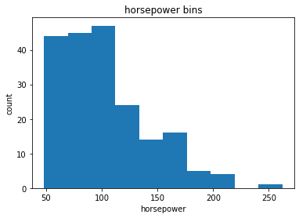

```python
%matplotlib inline
import matplotlib as plt
from matplotlib import pyplot
plt.pyplot.hist(df["horsepower"])

# set x/y labels and plot title
plt.pyplot.xlabel("horsepower")
plt.pyplot.ylabel("count")
plt.pyplot.title("horsepower bins")
```

```python
#We build a bin array with a minimum value to a maximum value by using the bandwidth calculated above.
#The values will determine when one bin ends and another begins.
bins = np.linspace(min(df["horsepower"]), max(df["horsepower"]), 4)
bins
```

```
array([ 48.        , 119.33333333, 190.66666667, 262.        ])
```

```python
#set group names
group_names = ['Low', 'Medium', 'High']
```

```python
#We apply the function "cut" to determine what each value of `df['horsepower']` belongs to.
df['horsepower-binned'] = pd.cut(df['horsepower'], bins, labels=group_names, include_lowest=True )
df[['horsepower','horsepower-binned']].head(20)
```

|  | horsepower | horsepower-binned |
| --- | --- | --- |
| 0 | 111 | Low |
| 1 | 154 | Medium |
| 2 | 102 | Low |
| 3 | 115 | Low |
| 4 | 110 | Low |
| 5 | 110 | Low |
| 6 | 110 | Low |
| 7 | 140 | Medium |
| 8 | 101 | Low |
| 9 | 101 | Low |
| 10 | 121 | Medium |
| 11 | 121 | Medium |
| 12 | 121 | Medium |
| 13 | 182 | Medium |
| 14 | 182 | Medium |
| 15 | 182 | Medium |
| 16 | 48 | Low |
| 17 | 70 | Low |
| 18 | 70 | Low |
| 19 | 68 | Low |

```python
#check number of cars in each bin
df["horsepower-binned"].value_counts()
```

```
Low       152
Medium     43
High        5
Name: horsepower-binned, dtype: int64
```

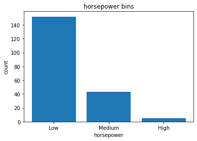

```python
#plotting the distribution of each bin
%matplotlib inline
import matplotlib as plt
from matplotlib import pyplot
pyplot.bar(group_names, df["horsepower-binned"].value_counts())

# set x/y labels and plot title
plt.pyplot.xlabel("horsepower")
plt.pyplot.ylabel("count")
plt.pyplot.title("horsepower bins")
```

## Indicator Variables

### We use indicator variables so we can use categorical variables for regression analysis in the later modules

##### Let's check our columns again:

```python
df.columns
```

```
Index(['symboling', 'normalized-losses', 'make', 'fuel-type', 'aspiration',
       'num-of-doors', 'body-style', 'drive-wheels', 'engine-location',
       'wheel-base', 'length', 'width', 'height', 'curb-weight', 'engine-type',
       'num-of-cylinders', 'engine-size', 'fuel-system', 'bore', 'stroke',
       'compression-ratio', 'horsepower', 'peak-rpm', 'city-mpg',
       'highway-mpg', 'price', 'city-L/100km', 'horsepower-binned'],
      dtype='object')
```

##### We'll create another 2 columns representing the categories of fuel (gas or deisel)

```python
dummy_variable_1 = pd.get_dummies(df["fuel-type"])
dummy_variable_1.head()
```

|  | diesel | gas |
| --- | --- | --- |
| 0 | 0 | 1 |
| 1 | 0 | 1 |
| 2 | 0 | 1 |
| 3 | 0 | 1 |
| 4 | 0 | 1 |

##### We'll change the column names for clarity

```python
dummy_variable_1.rename(columns={'gas':'fuel-type-gas', 'diesel':'fuel-type-diesel'}, inplace=True)
dummy_variable_1.head()
```

|  | fuel-type-diesel | fuel-type-gas |
| --- | --- | --- |
| 0 | 0 | 1 |
| 1 | 0 | 1 |
| 2 | 0 | 1 |
| 3 | 0 | 1 |
| 4 | 0 | 1 |

##### Now, we have to merge the new columns in our dataframe, and drop the "fuel-type" column

```python
# merge data frame "df" and "dummy_variable_1"
df = pd.concat([df, dummy_variable_1], axis=1)
```

```python
# drop original column "fuel-type" from "df"
df.drop("fuel-type", axis = 1, inplace=True)
```

#### We will do the same to the aspiration column:

```python
# get indicator variables of aspiration and assign it to data frame "dummy_variable_2"
dummy_variable_2 = pd.get_dummies(df['aspiration'])
# change column names for clarity
dummy_variable_2.rename(columns={'std':'aspiration-std', 'turbo': 'aspiration-turbo'}, inplace=True)
# show first 5 instances of data frame "dummy_variable_1"
dummy_variable_2.head()
```

|  | aspiration-std | aspiration-turbo |
| --- | --- | --- |
| 0 | 1 | 0 |
| 1 | 1 | 0 |
| 2 | 1 | 0 |
| 3 | 1 | 0 |
| 4 | 1 | 0 |

```python
# merge the new dataframe to the original datafram
df = pd.concat([df, dummy_variable_2], axis=1)
# drop original column "aspiration" from "df"
df.drop('aspiration', axis = 1, inplace=True)
```

#### Let's check finally our clean dataframe:

```python
df.head()
```

|  | symboling | normalized-losses | make | num-of-doors | body-style | drive-wheels | engine-location | wheel-base | length | width | ... | peak-rpm | city-mpg | highway-mpg | price | city-L/100km | horsepower-binned | fuel-type-diesel | fuel-type-gas | aspiration-std | aspiration-turbo |
| --- | --- | --- | --- | --- | --- | --- | --- | --- | --- | --- | --- | --- | --- | --- | --- | --- | --- | --- | --- | --- | --- |
| 0 | 3 | 122 | alfa-romero | two | convertible | rwd | front | 88.6 | 0.811148 | 0.890278 | ... | 5000.0 | 21 | 27 | 16500.0 | 11.190476 | Low | 0 | 1 | 1 | 0 |
| 1 | 1 | 122 | alfa-romero | two | hatchback | rwd | front | 94.5 | 0.822681 | 0.909722 | ... | 5000.0 | 19 | 26 | 16500.0 | 12.368421 | Medium | 0 | 1 | 1 | 0 |
| 2 | 2 | 164 | audi | four | sedan | fwd | front | 99.8 | 0.848630 | 0.919444 | ... | 5500.0 | 24 | 30 | 13950.0 | 9.791667 | Low | 0 | 1 | 1 | 0 |
| 3 | 2 | 164 | audi | four | sedan | 4wd | front | 99.4 | 0.848630 | 0.922222 | ... | 5500.0 | 18 | 22 | 17450.0 | 13.055556 | Low | 0 | 1 | 1 | 0 |
| 4 | 2 | 122 | audi | two | sedan | fwd | front | 99.8 | 0.851994 | 0.920833 | ... | 5500.0 | 19 | 25 | 15250.0 | 12.368421 | Low | 0 | 1 | 1 | 0 |

5 rows × 30 columns

### We can now save this clean dataframe to a new csv:

```python
df.to_csv('clean_df.csv')
```